# 1 Bayesian Networks: Discrete Case Notebook

# Graphical Representation

```r
library(bnlearn)
```

We first create a DAG with one node for each of the variables and no arcs

```r
dag <- empty.graph(nodes = c("A", "S", "E", "O", "R", "T"))
dag
```

```
  Random/Generated Bayesian network

  model:
   [A][S][E][O][R][T]
  nodes:                                 6
  arcs:                                  0
    undirected arcs:                     0
    directed arcs:                       0
  average markov blanket size:           0.00
  average neighbourhood size:            0.00
  average branching factor:              0.00

  generation algorithm:                  Empty
```

Next, we add the arcs that encode the direct dependencies between the variables in the survey. Age and Sex are not influenced by any other variables. But both have a direct influence on Education. Similarlly, Sex also influences Education. In turn, Education influences both Occupation and Residence. Finally, the preferred menas of transport are directly influenced by both Occupation and Residence.

```r
dag <- set.arc(dag, from = "A", to = "E")
dag <- set.arc(dag, from = "S", to = "E")
dag <- set.arc(dag, from = "E", to = "R")
dag <- set.arc(dag, from = "E", to = "O")
dag <- set.arc(dag, from = "O", to = "T")
dag <- set.arc(dag, from = "R", to = "T")
dag
```

```
  Random/Generated Bayesian network

  model:
   [A][S][E|A:S][O|E][R|E][T|O:R]
  nodes:                                 6
  arcs:                                  6
    undirected arcs:                     0
    directed arcs:                       6
  average markov blanket size:           2.67
  average neighbourhood size:            2.00
  average branching factor:              1.00

  generation algorithm:                  Empty
```

```r
print(modelstring(dag))
```

```
[1] "[A][S][E|A:S][O|E][R|E][T|O:R]"
```

```r
print(nodes(dag))
```

```
[1] "A" "S" "E" "O" "R" "T"
```

```r
print(arcs(dag))
```

```
     from to
[1,] "A"  "E"
[2,] "S"  "E"
[3,] "E"  "R"
[4,] "E"  "O"
[5,] "O"  "T"
[6,] "R"  "T"
```

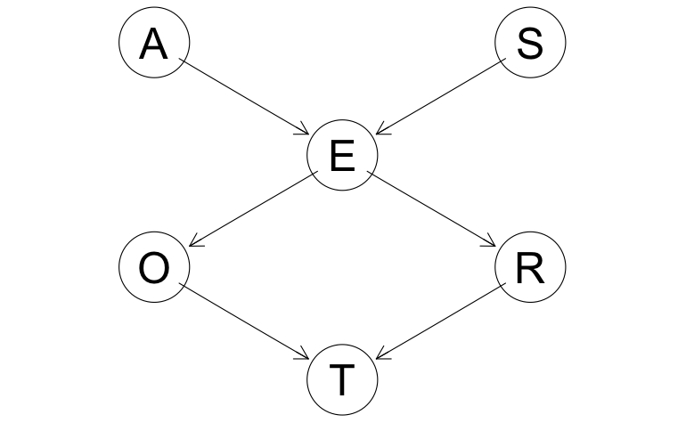

```r
graphviz.plot(dag)
```

```r
dag2 <- empty.graph(nodes = c("A", "S", "E", "O", "R", "T"))
arc.set <- matrix(c("A", "E",
                    "S", "E",
                    "E", "O",
                    "E", "R",
                    "O", "T",
                    "R", "T"),
                  byrow = TRUE, ncol = 2,
                  dimnames = list(NULL, c("from", "to")))
arcs(dag2) <- arc.set
all.equal(dag, dag2)
```

```
[1] TRUE
```

# Probabilisitc Representation

```r
A.lv <- c("young", "adult", "old")
S.lv <- c("M", "F")
E.lv <- c("high", "uni")
O.lv <- c("emp", "self")
R.lv <- c("small", "big")
T.lv <- c("car", "train", "other")
```

## One Dimensional Tables

```r
A.prob <- array(c(0.30, 0.50, 0.20), dim = 3,
                dimnames = list(A = A.lv))
print(A.prob)
```

```
A
young adult   old
  0.3   0.5   0.2
```

```r
S.prob <- array(c(0.60, 0.40), dim = 2,
                dimnames = list(S = S.lv))
print(S.prob)
```

```
S
  M   F
0.6 0.4
```

## Two Dimensional Tables

```r
O.prob <- array(c(0.96, 0.04, 0.92, 0.08), dim = c(2, 2),
                dimnames = list(O = O.lv, E = E.lv))
R.prob <- array(c(0.25, 0.75, 0.20, 0.80), dim = c(2, 2),
                dimnames = list(R = R.lv, E = E.lv))
print(O.prob)
```

```
      E
O      high  uni
  emp  0.96 0.92
  self 0.04 0.08
```

```r
print(R.prob)
```

```
       E
R       high uni
  small 0.25 0.2
  big   0.75 0.8
```

## Three Dimensional Tables

```r
E.prob <- array(c(0.75, 0.25, 0.72, 0.28, 0.88, 0.12, 0.64,
                  0.36, 0.70, 0.30, 0.90, 0.10), dim = c(2, 3, 2),
                dimnames = list(E = E.lv, A = A.lv, S = S.lv))
T.prob <- array(c(0.48, 0.42, 0.10, 0.56, 0.36, 0.08, 0.58,
                  0.24, 0.18, 0.70, 0.21, 0.09), dim = c(3, 2, 2),
                dimnames = list(T = T.lv, O = O.lv, R = R.lv))
# print(E.prob)
print(T.prob)
```

```
, , R = small

       O
T        emp self
  car   0.48 0.56
  train 0.42 0.36
  other 0.10 0.08

, , R = big

       O
T        emp self
  car   0.58 0.70
  train 0.24 0.21
  other 0.18 0.09
```